# 第9回 散布図・共分散・相関係数

## まとめ

- **困りごと**：共分散は単位で大きさが変わる（−4 と −240）
- **そこで**：ずれを、ふつうのずれの何個分かにそろえる
- **相関係数**：共分散 ÷ 標準偏差の積。向きは共分散のまま、  
  大きさを −1 から 1 にそろえる
- **2 つの数**：5 人は −0.894、36 年は −0.737

関係が 1 つの数になった。では、数だけを見て大丈夫か  
これを次のトピックで見る

経済データ入門

第9回 — Topic04

相関と因果

一緒に動けば、原因か？

## この回の道のりと「5人」シート

1

散布図

演習 9-1

36 年の散布図

2

共分散

演習 9-2

36 年の共分散

3

相関係数

演習 9-3

分で数えた相関

4

相関と因果

演習 9-4

外れ値の前後

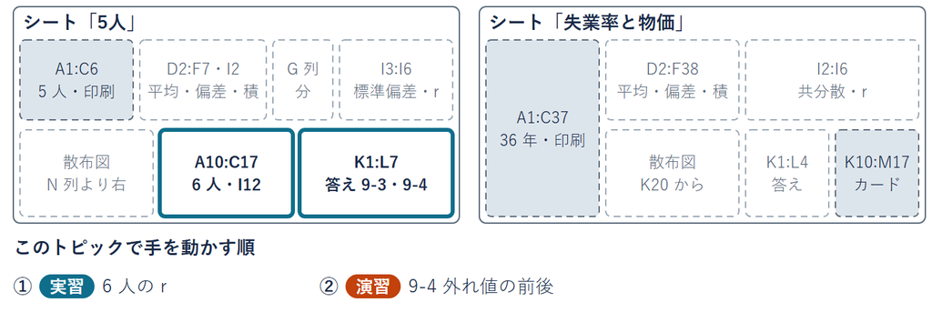

置き場は「5人」の 6 人の表 A10:C17・I12 と答え欄 L4:L7

## 1 つの数の便利さ

5 人は −0.894、36 年は −0.737  
同じ物差しで比べられるようになった

- **でも**：1 つの数は、散布図の形を 1 つの数にまとめている  
  （形の情報は消えている）
- **確かめること 1**：外れた点が 1 つあると、どうなるか
- **確かめること 2**：曲がった関係だと、どうなるか
- **確かめること 3**：一緒に動けば、原因と言えるか  
  相関＝一緒に動く関係、因果＝原因と結果のつながり

## 6 人目の F

[figure not shown]

**サンプルデータ**：6 人目の F（6 日・12 時間）  
右下がりの流れから 1 人だけ大きく外れた点を、外れ値と呼ぶ

## 外れた点と散布図

決まり

数の前に、まず散布図を見る

- **1 人で**：r は −0.894 から −0.134 まで動く
- **数だけなら**：「ほとんど関係なし」に見えてしまう
- **散布図なら**：右上に 1 つだけ離れた点が、目ですぐ分かる
- **消す前に**：打ち間違いか、本当にそういう人かを調べる

## デモ：相関の実験室

数の話

共分散 ＝ 偏差の積の平均（人数 n で割る）  
相関係数 r ＝ 共分散 ÷（x の標準偏差 × y の標準偏差）

- **何を見るか**：点を動かすと、  
  平均の十字・区画の色・積・共分散・r が一緒に動く
- **図の意味**：左は散布図と平均の十字と積の長方形、右は共分散と r
- **操作**：点のドラッグ・つまみ・タブ・F のボタン・元に戻す

ミッション F を足して r の変わり方を見る

※ 次のスライドへ進むときは、デモの枠の外を一度クリックしてから ← → キーを押す

[interactive chart not shown]

## F を足した 6 人の相関係数

1. **打つ**：A17:C17 に F・6・12  
   12〜16 行目は印刷済みの 5 人
2. **関数で**：I12 に  
   `=CORREL(B12:B17,C12:C17)`
3. **見る**：I12 が −0.134  
   I6 の −0.894 から大きく動いた

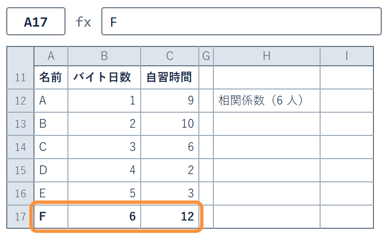

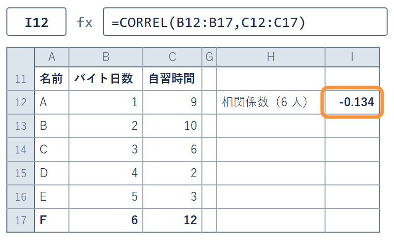

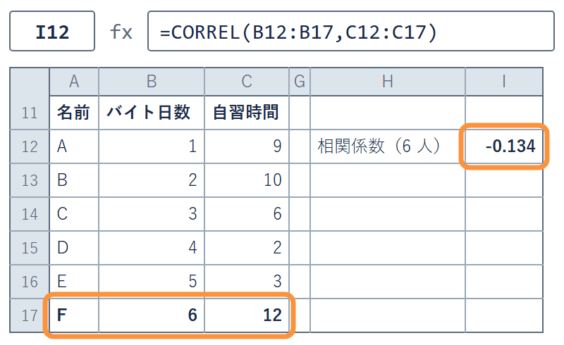

✋ 動画を止めて ①〜③ を進め、I12 が出たら再生に戻る

## 演習 9-4 外れ値の前後

演習 9-4

F を足す前と後、F の自習を変えたときの相関係数を比べる

1. **前と後**：I6（T3 で CORREL を入れたセル）の値を L4 に、I12 の値を L5 に  
   小数第 3 位までの数字で打つ（式でつながない）
2. **予想**：F の自習が 12 時間でなく 1 時間なら、r は  
   5 人の −0.894 より 強くなる／同じ／弱くなる のどれか
3. **確かめる**：C17 を 1 に打ち替え、I12 の値を L6 に打つ
4. **1 文**：L7 に「F が流れから外れると r は〜  
   流れに乗ると r は〜」と書き、C17 を 12 に戻す

**サンプルデータ**：シート「5人」の 6 人の表（A10:C17）

## 曲がった関係

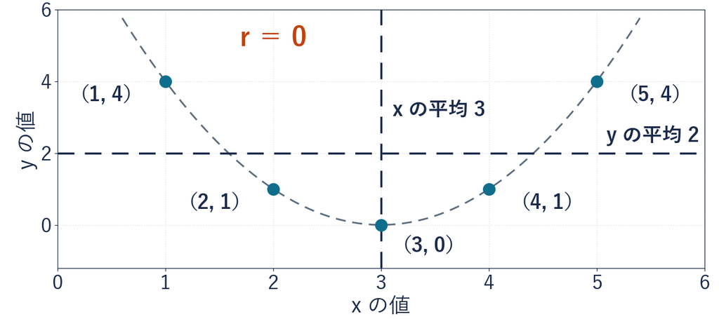

十字で見た積 −4, +1, 0, −1, +4 が打ち消し合い、r ＝ 0  
直線的な関係がないだけ（例：気温と電気代）

**サンプルデータ**：y ＝ 4, 1, 0, 1, 4（x と 3 の差の 2 乗で決まる）

## たしかめ アイスと水の事故

夏はアイスの売上も水の事故も増える（作った例の話）  
アイスの販売をやめれば、水の事故は減るか

**1 減る**

**2 減らない**

3 この情報だけでは  
分からない

1 つ決めてから先へ。答えは、次のページで出す

## 第 3 の要因

[figure not shown]

答えは 3 番。アイスが原因とは言えない  
暑さが両方を動かしていることがありうる

用語

**見かけの相関**：どちらも相手の原因ではないのに  
一緒に動いて見える関係（第 3 の要因などのせい）

## 相関の 4 つの筋書き

- **筋書き 1**：x が y の原因（バイトで時間が取られ、自習が減る）
- **筋書き 2**：逆に、y が x の原因  
  （自習しない人ほど、空いた時間にバイトを入れる）
- **筋書き 3**：第 3 の要因が、両方を動かす  
  （お金に困っている人は、バイトを増やし、勉強にも身が入らない）
- **筋書き 4**：ただの偶然（5 人だけなので、たまたま）

相関係数は一緒に動く度合いだけ。原因のこともあるし、  
そうでないこともある。どれかは相関だけでは決められない

## 景気と 36 年

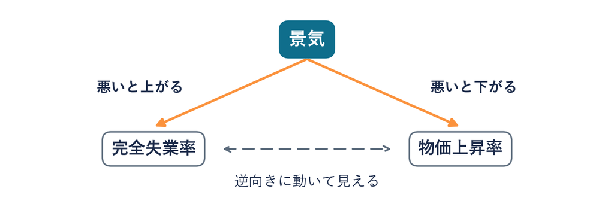

- **景気が悪いと**：モノが売れない → 会社は人を減らす  
  （失業率↑）・値上げしにくい（物価上昇率↓）
- **36 年の −0.737**：景気が両方を逆向きに動かした見方がありうる
- **ほかの見方も**：失業率と物価が直接つながっている面もありうる。  
  相関だけでは決められない

## 相関の読み方

**相関の読み方：一緒に動くことと、原因であることは別の話**

**言える**  
失業率と物価上昇率は  
この 36 年、逆向きに動いた  
（r ＝ −0.737）

**言えない**  
失業率を上げれば  
物価が下がる  
（相関だけでは言えない）

## Q&A 相関係数の読み方

Q1 r ＝ −0.7 は「70% 関係がある」か

割合ではない。大きさ 0.7 で目安の 0.7（強い）  
に届くという目盛りの読み

Q2 r ＝ 0 なら、関係がないか

**直線的な関係がない**だけ。U 字のように曲がっているかもしれない

Q3 r が大きければ、原因と言えるか

相関だけでは言えない（原因のこともある）  
**第 3 の要因**を 1 つ挙げて確かめる

## この回のまとめ

手順

散布図1 行を 1 点にして、向きを目で見る

共分散偏差の積の平均。符号で向きを言う

相関係数単位を消して、強さを −1 から 1 で言う

読み方外れた点・曲がった関係・第 3 の要因を確かめる

「〜すると〜が増える」と聞いたら、第 3 の要因を探す  
この点の雲に、1 本の線を引いてみたい。それはこの先で